# Text data with a twist

Bennett Kleinberg

20 Sept. 2022

Part 1: Research talk

Behavioural inferences from text data *with a twist*

## The Real World Worry Datasets

- crowd-sourced task on Prolific Academic
- UK sample of participants
  - Step 1: obtaining their emotions about COVID-19
  - Step 2: asking them to write a text that expresses the emotion
    - a long text of at least 500 characters
    - a Tweet-sized text

Final dataset: text data with corresponding values on 8 emotions

## Repeated-measures design

We wanted to more than just snapshot information.

- April 2020: $n=2500$ (= 5,000 texts + emotion data) (Kleinberg, Vegt, and Mozes 2020)
- April 2021: $n=1698$ (= 3,396 texts + emotion data) (Mozes, Vegt, and Kleinberg 2021)
- April 2022: $n=1152$ (= 2,304 texts + emotion data) (Vegt, Mozes, and Kleinberg 2022)

How did individuals (fail to) cope? **What do text data reveal?**

## Text data from the social science view

- desperate need for valid proxy measures
- classical approaches are becoming outdated (Hofman et al. 2021)
- text data (and their computational methods) offer a whole new dimension to the picture (Gentzkow, Kelly, and Taddy 2019)

Currently: the eager yet methodologically-skeptical phase

## Person X (April 2020)

> I feel grateful that I am not suffering and thankful to all the people who are helping out. But it’s frustrating seeing people deliberately assume the rules do not apply to them and continue to wander out and about, too close to people and more than once a day. It feels like we are not yet in the worst of it, and the actions of people feel like the government will have to take more severe actions soon. I am not looking forward to it but also limiting the amount I think about it as it is all so stressful.

## Person X (April 2021)

> I feel more hopeful than I’ve felt in a long time and I’m happy the vaccine roll out seems to be going so well. I am anxious about what going “back to normal” looks like as I want the freedom to make permanent changes to life like working from home. I am frustrated at the government as I feel they have not done enough and have looked after people who look like them rather than those who need it the most. I think it’s likely that fewer people will vote for them in the next election because of their coronavirus response.

## Person X (April 2022)

> I feel grateful that the worst of the pandemic is over and that we are slowly returning to some sense of normalcy. I am anxious about the future and what permanent changes the pandemic will have on our society. I am frustrated with the government as I feel they could have done more to prevent the spread of the virus. I think it’s likely that people will continue to be divided on the issue of the government’s response to the pandemic.

Another example

## Person Y (April 2020)

> I am angry due to the fact that people are unaware of the fact that Corona virus is a common flu virus and anybody who has got flu in the past will still have it in their body. There is no test out as yet for covid19 (if there is any virus like that at all). The figure of people infected is just magnified artificially […] This pandemic is a global cover up for something more sinister.

## Person Y (April 2021)

> At this moment of time the social media and the mainstream channels have been overtaken by the government to forward their global re-set agenda as announced by the UN. Covid is just an excuse to usher their agenda. […] This re-set is the brainchild of the elite who control their own organisations like UN, UNESCO, WHO. IMF etc and in turn these organisations control the government of countries. People like Bill Gates, G. Soros, Rothchilds, Morgan etc have invested billions in vaccinations and to bribe these institutions and social media so that they only give false informations about this fake pandemic and to frighten the people. […]

## Person Y (April 2022)

> The global reset is in full swing. The elite have successfully taken over the world and are now implementing their agenda. The masses have been controlled through various means such as isolation, lockdown, vaccinations, and covid passports. The death rate from the covid virus is less than one percent, but the media continues to spread lies about the virus and the pandemic. […]

… the twist

## GPT-3 and prompting

- we used GPT-3 (Brown et al. 2020) to complete text requests
  - 175 billion parameter model trained on 300 billion tokens
  - used for question answering, text summarisation, classification, etc.
  - very controversial when announced
- core idea: instructing the model with *prompts*

## Brief demo

```r
prompt_input = 'Write an abstract about using NLP for social science: '
```

Output:

> NLP could be used to study how people communicate with each other on social media. This could involve looking at the use of specific words, the emotions conveyed in posts, and the overall tone of communication. This research could help to understand how people interact with each other online and could be used to improve social media platforms.

## Our approach

- we prompted GPT-3 with the texts from 2020 and 2021
- and instructed it to write the text of that same person for 2022

## Example I (generated text)

> The global reset is in full swing. The elite have successfully taken over the world and are now implementing their agenda. The masses have been controlled through various means such as isolation, lockdown, vaccinations, and covid passports. The death rate from the covid virus is less than one percent, but the media continues to spread lies about the virus and the pandemic. […]

## Example I (true text)

> As planned by the cabal elites they were partially successful in carring out their plans for the new global order, where they had planned for decimating the lower/middle class by enforcing lockdown and destroying their mode of income. It was a multi-pronged attack supported by the fake stream media like BBC, CNN etc who were given big money to spread lies. […] We are living in dark ages and the culprit is not the fake virus, but the agenda behind it.

## Example II (generated text)

> I feel grateful that the worst of the pandemic is over and that we are slowly returning to some sense of normalcy. I am anxious about the future and what permanent changes the pandemic will have on our society. I am frustrated with the government as I feel they could have done more to prevent the spread of the virus. I think it’s likely that people will continue to be divided on the issue of the government’s response to the pandemic.

## Example II (true text)

> I have mixed feelings about the pandemic. While I am happy that things have opened up again and travel and events are possible once more, there is still an awful lot of covid about. I recently caught it and, despite being fully jabbed and boosted, I was horribly ill with it. It makes me nervous about my parents catching it as they are older and more vulnerable. I do wonder whether there will be another surge of covid that causes more lockdowns in the future. It also makes me worry about a new pandemic.

## Remember…

- GPT-3 has no way of knowing the “true” texts
- and we have only used *zero-shot learning* ($\neq$ classic supervised machine learning)

## What is going on here?

Unique dataset: we know the “ground truth” textual responses

1. quantitative comparison of both versions
   - semantic similarities with Universal Sentence Encodings (Cer et al. 2018)
2. exploring the processes of GPT-3

## Quantitative results

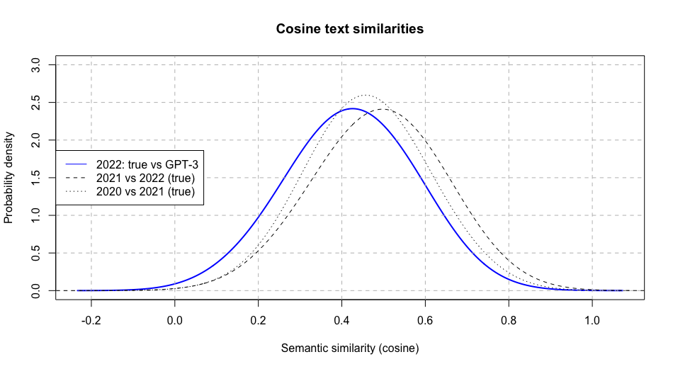

## Which prompt information does it use?

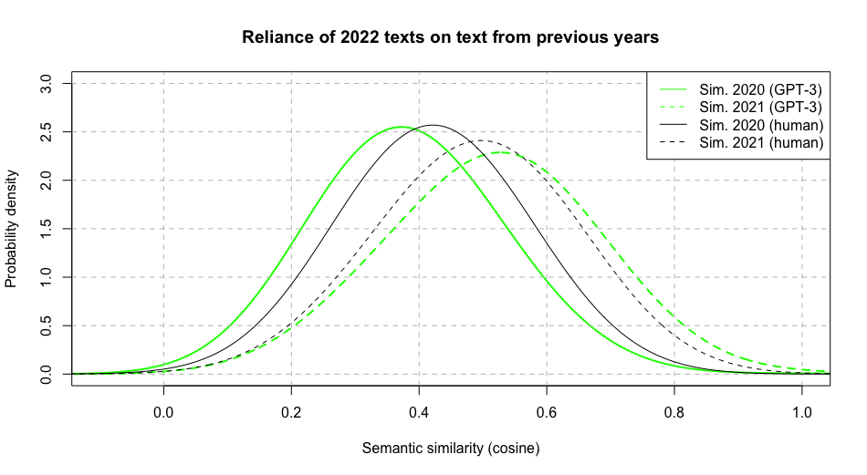

## Which words does it introduce?

Results from bootstrapped n-gram differentiation test (Mozes, Vegt, and Kleinberg 2021):

| GPT-3 | Humans |
| --- | --- |
| grate | covid |
| pandem | mask |
| slowli | still |
| final | wear |
| futur | test |
| able | wear_mask |
| return | now |
| world | peopl |
| friend_famili | live |

## Now what?

We have an AI language model that:

- generates texts very similar to the real texts that participants wrote one year later
- cannot be explained as simple auto-regressive generation (unless humans do so too)

The bigger picture: A game-changer for CSS?

## Hard problems

- many social science problems require an understanding (ideally: causal) to address them
- solution: careful experimental research

**But:**

- *the hardest societal problems are (very) difficult to study experimentally*

## Human simulation model

What if we could use an AI model for *hard-to-run* studies?

- Medical research: animal models
- CSS research: *human simulation models*

Both are imperfect and limited. But they offer whole new paths for research.

## Example: polarisation

Currently:

- widely problematic
- but: gap in understanding *how* one develops polarised (potentially extreme) views

With a human simulation model…

## Polarisation in a sandbox

When does one develop polarised views? –> *feed the model with extreme vs neutral content, assess the effect on attitudes*

How can we mitigate polarisation? –> *train a polarised model (e.g., on Stormfront), feed it contradicting information vs control, assess attitudes*

The model becomes the participant.

## The big “…if”

- the “human simulation model” rests on a bold assumption
- research task for now:
  - testing the assumption
  - mapping out large language models as human participants

## Very early findings

- GPT-3 seems to possess a theory of mind (Sally-Anne task successful) (Weber 2021)
- Cognitive benchmark tasks show similar mistakes to humans (e.g., CRT, Linda problem) (Binz and Schulz 2022)
- GPT-3 displays creativity similar to humans on the AUT (Stevenson et al. 2022)

**Who** is GPT-3 then?

## Fresh findings

- Hexaco personality:
  - profile resembling female participants (e.g., high in honesty-humility)
- Human Values Scale:
  - high: benevolence, universalism, self-direction
  - low: tradition, conformity, power
- Demographics:
  - 66.73% female, $M_{age}=27.51$ years (range: 13; 75)

Ongoing work: (Miotto, Rossberg, and Kleinberg (ongoing))

## Exciting challenges

- ethical questions; limitations of verbal behaviour
- test set exposure
- accessibility for non-technical researchers (–> [R package `rgpt3`](https://github.com/ben-aaron188/rgpt3))

An example of where “wild ideas” could lead us.

Part 2: Contribution to CSS Services

## Objectives

- short term: solving the data access dilemma
- long term: better methods and tools

## Short term

- data access as central problem to more meaningful research (example: EHR, police data)
- open secret of Twitter data
- dilemma between sharing and privacy
- particularly problematic for text data (high promise, but high privacy risk)
- solution: text anonymisation

## Textwash

- harnessing machine learning and NLP to identify and replace *potentially sensitive information*
- lightweight, offline, data-averse, open-source [python package](https://github.com/maximilianmozes/textwash)
- retains data usefulness for downstream NLP tasks!

Empirically validated on TILD criteria: technical, information loss, de-anonymisation

Results indicate state-of-the-art anonymisation (Kleinberg, Davies, and Mozes 2022; Kleinberg et al. 2017; Mozes and Kleinberg 2021)

## Brief demo

```bash
python3 anon.py --input_dir test_dir --output_dir anonymised_dir --cpu
```

Input:

> Jane Doe was born in December 1978 and is currently living in London, United Kingdom.

Output:

> PERSON_FIRSTNAME_1 PERSON_LASTNAME_1 was born in DATE_1 and is currently living in LOCATION_1, LOCATION_2.

## Further development

- full anonymisation suite
- multiple languages, customisation, ease-of-use
- improving the tool
- further integration into multiplicators (archives, data labs, institutes)

**Goal: GESIS anonymisation suite**

## Long term

Better methods and tools

1. solving the reliance on black box methods (fundamental methods research)
2. shifting the power-balance back to open research (developing daring tools ourselves)

## Thanks.

- bennett.kleinberg@tilburguniversity.edu
- https://bkleinberg.net/

## Additional data

## 1 year in the pandemic

| Emotion | Phase 1 | Phase 2 | Bayes Factor |
| --- | --- | --- | --- |
| anger | 3.81 (2.21) | 3.55 (2.37) | 213.89 (-) |
| anxiety | 6.46 (2.31) | 5.08 (2.51) | > 10^95 (-) |
| desire | 2.86 (1.98) | 3.57 (2.26) | > 10^30 (+) |
| disgust | 3.12 (2.12) | 2.87 (2.18) | 219.97 (-) |
| fear | 5.60 (2.28) | 3.77 (2.28) | > 10^163 (-) |
| happiness | 3.60 (1.87) | 4.32 (2.01) | > 10^34 (+) |
| relaxation | 3.89 (2.11) | 4.54 (2.24) | > 10^22 (+) |
| sadness | 5.55 (2.33) | 4.69 (2.57) | > 10^33 (-) |
| worry | 6.57 (1.75) | 4.95 (2.01) | > 10^200 (-) |

## Is that the whole story?

- overall: things got better
- negative emotions went down
- positive emotions went up

We took a closer look with *clustering techniques* (k-means)…

## Coping from 2020 –> 2021

| Emotion variable | Cluster 1 (well-coping) | Cluster 2 (resignation) |
| --- | --- | --- |
| Anger change | -1.74 (2.08) | 0.88 (2.19) |
| Anxiety change | -3.06 (2.13) | -0.09 (1.96) |
| Desire change | 1.21 (2.44) | 0.33 (2.27) |
| Disgust change | -1.36 (2.14) | 0.61 (2.28) |
| Fear change | -3.52 (1.94) | -0.53 (1.94) |
| Happiness change | 1.88 (2.10) | -0.19 (1.90) |
| Relaxation change | 2.16 (2.24) | -0.53 (2.01) |
| Sadness change | -2.70 (2.37) | 0.55 (2.07) |
| Worry change | -2.48 (1.85) | -0.97 (1.66) |
| % of sample | 43.58 | 56.42 |

## Coping from 2021 –> 2022

| Emotion variable | Cluster 1 (well-coping) | Cluster 2 (resignation) |
| --- | --- | --- |
| Anger change | -2.38 (2.11) | 0.56 (1.88) |
| Anxiety change | -2.82 (1.94) | 0.30 (1.97) |
| Desire change | 0.27 (2.42) | -0.52 (2.24) |
| Disgust change | -1.74 (2.16) | 0.51 (1.85) |
| Fear change | -2.52 (2.02) | 0.17 (1.72) |
| Happiness change | 1.65 (2.09) | -0.34 (1.94) |
| Relaxation change | 2.24 (2.33) | -0.53 (2.01) |
| Sadness change | -3.27 (2.18) | 0.28 (2.04) |
| Worry change | -1.79 (1.82) | -0.62 (1.66) |
| % of sample | 40.45 | 59.55 |

## In summary

- grand trend towards emotional adjustment (positive emotions increase, negative emotions decrease)
- but evidence for hidden sub-groups with distinct coping patterns
  - well-coping individuals vs emotional resignation
  - evident in both transitions: 2020 –> 2021 and 2021 –> 2022

## Clusters migration?

|  | resignation_2022 | well-coping_2022 |
| --- | --- | --- |
| resignation_2021 | *322* | 319 |
| well-coping_2021 | *364* | 147 |

Cluster membership in 2021 was associated with that of 2022, $\chi^2(1) = 51.18$, $p<.001$

Reason for concern: 59.55% remained or became poorly adjusted!

Ongoing work: explanatory modelling of emotion adjustment.

What about the text data?

## One year in the pandemic (frequentist)

| Emotion | Phase 1 | Phase 2 | Cohen’s d [99% CI] |
| --- | --- | --- | --- |
| anger | 3.81 (2.21) | 3.55 (2.37) | (-) 0.10 [0.04; 0.17] |
| anxiety | 6.46 (2.31) | 5.08 (2.51) | (-) 0.55 [0.48; 0.62] |
| desire | 2.86 (1.98) | 3.57 (2.26) | (+) 0.30 [0.24; 0.36] |
| disgust | 3.12 (2.12) | 2.87 (2.18) | (-) 0.10 [0.04; 0.17] |
| fear | 5.60 (2.28) | 3.77 (2.28) | (-) 0.75 [0.68; 0.82] |
| happiness | 3.60 (1.87) | 4.32 (2.01) | (+) 0.32 [0.26; 0.38] |
| relaxation | 3.89 (2.11) | 4.54 (2.24) | (+) 0.26 [0.19; 0.32] |
| sadness | 5.55 (2.33) | 4.69 (2.57) | (-) 0.32 [0.25; 0.38] |
| worry | 6.57 (1.75) | 4.95 (2.01) | (-) 0.86 [0.78; 0.93] |

## Did the language change?

| Increased usage | Decreased usage |
| --- | --- |
| vaccin* | worker |
| covid | stay_home |
| look_forward | news |
| open | nhs |
| forward | stay |
| year | hous |
| school | worri |
| return | serious |
| restrict | isol |
| pandem | stress |

* Participants who mentioned the vaccine had a larger reduction in anxiety ($d=0.22$) and sadness ($d=0.17$).

## Deltas 2021-2022

| var | M | SD | Bayes Factor |
| --- | --- | --- | --- |
| Anger (delta) | -0.63 | 2.45 | > 10^14 (-) |
| Anxiety (delta) | -0.97 | 2.49 | > 10^33 (-) |
| Desire (delta) | -0.20 | 2.35 | 2.17 (-) |
| Disgust (delta) | -0.40 | 2.27 | > 10^5 (-) |
| Fear (delta) | -0.92 | 2.27 | > 10^36 (-) |
| Happiness (delta) | 0.46 | 2.23 | > 10^8 (+) |
| Relaxation (delta) | 0.59 | 2.54 | > 10^10 (+) |
| Sadness (delta) | -1.16 | 2.73 | > 10^39 (-) |
| Worry (delta) | -1.09 | 1.82 | > 10^75 (-) |

## N-gram differentiation

| Increased usage | Decreased usage |
| --- | --- |
| covid | vaccin |
| mask | hope |
| still | lockdown |
| wear | see |
| test | famili |
| wear_mask | friend |
| now | look |
| peopl | abl |
| live | end |
| restrict | go |

## Does it fail where we expect it to?

There are things the model just cannot know: dramatic life events.

- 33.85% reported significant life events: e.g., death, job change, financial problems, pregnancy

No effect of life event intensity on GPT-3-to-true similarity, $\beta = 0.00, p = .14$

## Example III (GPT-3)

> I am still angry at the government for their handling of the pandemic and the NHS. I think that many people have died needlessly and that the government could have done more to prevent this. I am also angry that many people are now out of work and struggling to make ends meet. The government’s incompetence is going to be felt in this country for a very long time.

## Example III (true)

> Angry at how the government have handled the whole situation. I feel very let down at a lot of the decisions made. They have now implemented measures on ‘saving the economy’ which will hit lower income families more due to the government giving out contracts during the pandemic to companies who were unable to fulfil the order to the capacity required.understand it was unprecedented but as the pandemic went on the same mistakes were being made time and time again. Getting rid of lockdown measures too early to create short term benefits whilst in the long term we would suffer.

## Example IV (GPT-3) low sim.

> I am so grateful that this is finally over. I can’t believe we made it through. I am so grateful for the things I have learned, and for the people I have met. I am so grateful for the love and support I have received. I am so grateful for the strength I have found within myself. I am so grateful for the chance to start again.

## Example IV (true) low sim.

> I feel like the media is not reporting on COVID anymore to try and ignore the issues hoping it will go over time. I believe the go ernment are planning to ““““live with covid”““” and hoping most people will contract it like we contract the flu around the winter. I believe this is the sad reality. I know more people getting covid currently, than at the beginning of the pandemic, and those peopl eare being affected also by ““““long covid”““” which is qwuite scary as I am not seeing any mention of this in the global media

## Example V (GPT-3) low sim.

> I am so excited to finally be able to see my friends and family again after so long! It feels like a weight has been lifted off my shoulders and I can finally start living my life again. I’m also excited to start looking for a new job as my old one ended last year, and I’m ready to start fresh and see what the world has to offer me. I’m feeling positive about the future and am looking forward to what the next year has in store for me.

## Example V (true) low sim.

> Frustrated that people aren’t isolating when they have covid. After nearly 2 years of shielding it all seems like it was a huge waste of time for it to just be literally rubbed in my face now. that it’s at such a high level all over now, concerning about new variants. Hopeful that if/when I get it again it will continue to be a mild case. am concerned about how coronavirus will continue to develop, if we will ever get to the point where we can live without fear; I have had 4 vaccines now and am wondering how frequently we will be getting boosters. I definitely feel like I have had some post traumatic stress in relation to covid - and specifically due to shielding. It felt like it had got better in recent times, but just going for a walk to see the lambs brought back all the memories of the daily walk exactly the same way.

## References

Binz, Marcel, and Eric Schulz. 2022. “Using Cognitive Psychology to Understand GPT-3.” https://doi.org/10.48550/ARXIV.2206.14576.

Brown, Tom, Benjamin Mann, Nick Ryder, Melanie Subbiah, Jared D Kaplan, Prafulla Dhariwal, Arvind Neelakantan, et al. 2020. “Language Models Are Few-Shot Learners.” In *Advances in Neural Information Processing Systems*, edited by H. Larochelle, M. Ranzato, R. Hadsell, M. F. Balcan, and H. Lin, 33:1877–1901. Curran Associates, Inc. https://proceedings.neurips.cc/paper/2020/file/1457c0d6bfcb4967418bfb8ac142f64a-Paper.pdf.

Cer, Daniel, Yinfei Yang, Sheng-yi Kong, Nan Hua, Nicole Limtiaco, Rhomni St. John, Noah Constant, et al. 2018. “Universal Sentence Encoder for English.” In *Proceedings of the 2018 Conference on Empirical Methods in Natural Language Processing: System Demonstrations*, 169–74. Brussels, Belgium: Association for Computational Linguistics. https://doi.org/10.18653/v1/D18-2029.

Gentzkow, Matthew, Bryan Kelly, and Matt Taddy. 2019. “Text as Data.” *Journal of Economic Literature* 57 (3): 535–74. https://doi.org/10.1257/jel.20181020.

Hofman, Jake M, Duncan J Watts, Susan Athey, Filiz Garip, Thomas L Griffiths, Jon Kleinberg, Helen Margetts, et al. 2021. “Integrating Explanation and Prediction in Computational Social Science.” *Nature* 595 (7866): 181–88.

Kleinberg, Bennett, Toby Davies, and Maximilian Mozes. 2022. “Textwash - Automated Open-Source Text Anonymisation.” *arXiv:2208.13081*, August. https://doi.org/10.48550/arXiv.2208.13081.

Kleinberg, Bennett, Maximilian Mozes, Yaloe van der Toolen, and Bruno Verschuere. 2017. “NETANOS-Named Entity-Based Text Anonymization for Open Science.” *OSF Preprint*. https://osf.io/preprints/w9nhb/.

Kleinberg, Bennett, Isabelle van der Vegt, and Maximilian Mozes. 2020. “Measuring Emotions in the COVID-19 Real World Worry Dataset.” In *Proceedings of the 1st Workshop on NLP for COVID-19 at ACL 2020*. Online: Association for Computational Linguistics. https://www.aclweb.org/anthology/2020.nlpcovid19-acl.11.

Miotto, Marilu, Nicola Rossberg, and Bennett Kleinberg. (ongoing). “Who Is GPT-3?” (ongoing).

Mozes, Maximilian, and Bennett Kleinberg. 2021. “No Intruder, No Validity: Evaluation Criteria for Privacy-Preserving Text Anonymization.” *arXiv:2103.09263 [Cs]*, March. http://arxiv.org/abs/2103.09263.

Mozes, Maximilian, Isabelle van der Vegt, and Bennett Kleinberg. 2021. “A Repeated-Measures Study on Emotional Responses After a Year in the Pandemic.” *Scientific Reports* 11 (1): 23114. https://doi.org/10.1038/s41598-021-02414-9.

Stevenson, Claire, Iris Smal, Matthijs Baas, Raoul Grasman, and Han van der Maas. 2022. “Putting GPT-3’s Creativity to the (Alternative Uses) Test.” arXiv. https://doi.org/10.48550/arXiv.2206.08932.

Vegt, Isabelle van der, Maximilian Mozes, and Bennett Kleinberg. 2022. “A Multi-Year Study on Insights into Emotional Coping During the Pandemic.”

Weber, Julian. 2021. “Does GPT-3 Have a Theory of Mind?” *Medium*. https://medium.com/@julian78w/does-gpt-3-have-a-theory-of-mind-890fb0c7bf48.